# Homework 5

## Exercise 2

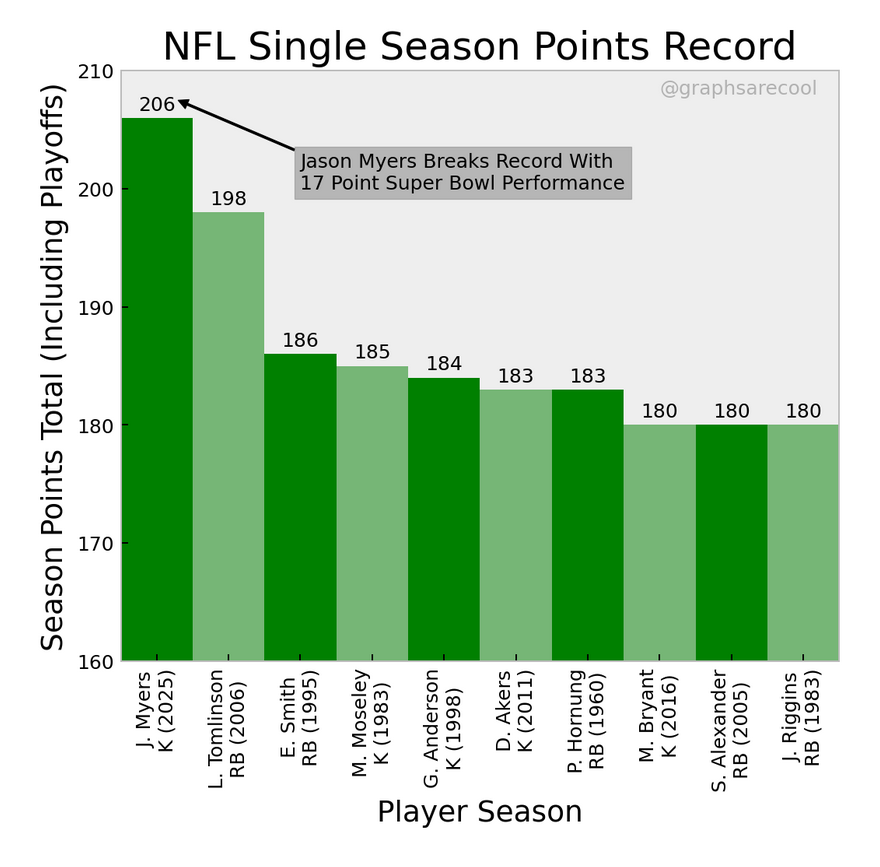

b. The mark being used are rectangles. x-position -> player and season y-position -> total seasonal points color -> no variable text -> record breaking notes label

3. Jason Myers set a new NFL single- season record surpassing LaDainian Tomlinson’s long standing record including playoffs.
4. It is very visually appealing with the two shades of green contrasting. There are labels and texts that clearly explain what each bar means. They are sorted in descending order, making comparison effortless.
5. I can make bar charts, sort bars by value, customize titles and subtitles, axis labels and subtitles,color choices, text annotations.
6. The labels on the x-axis that shows their names and the seasons they played. The labeling would be difficult if it was not set like that in the data set. I also don’t know how to make the color gradient yet so I would find that challenging.

## Exercise 3

```r
library(tidyverse)
library(vegawidget)
```

#### 1

1. Create a graphic that shows the high temperature in Seattle each day. ##### Load the data

```r
weather <- read_csv("weather-with-dates.csv")
head(weather)
```

```
# A tibble: 6 × 11
  location date       precipitation temp_max temp_min  wind weather  year month
  <chr>    <date>             <dbl>    <dbl>    <dbl> <dbl> <chr>   <dbl> <dbl>
1 Seattle  2012-01-01           0       12.8      5     4.7 drizzle  2012     1
2 Seattle  2012-01-02          10.9     10.6      2.8   4.5 rain     2012     1
3 Seattle  2012-01-03           0.8     11.7      7.2   2.3 rain     2012     1
4 Seattle  2012-01-04          20.3     12.2      5.6   4.7 rain     2012     1
5 Seattle  2012-01-05           1.3      8.9      2.8   6.1 rain     2012     1
6 Seattle  2012-01-06           2.5      4.4      2.2   2.2 rain     2012     1
# ℹ 2 more variables: day <dbl>, day_of_week <dbl>
```

```r
my_spec <-
  list(
    `$schema` = vega_schema(),
    data = list(values = weather),
    height = 250, width = 500,
    transform = list(list(filter = "datum.location == 'Seattle'")),
    mark = "line",
    encoding = list(
      x = list(field = "date", type = "temporal", title = "Date"),
      y = list(field = "temp_max", type = "quantitative", title = "High Temperature")
      )
)
my_spec|> as_vegaspec()
```

[interactive chart not shown]

2. Now modify this so that the temperatures for the same day of the year are overlaid on top of each other for the several years in the data set.

```r
'{
  "$schema": "https://vega.github.io/schema/vega-lite/v5.json",
  "data": {
    "url": "https://calvin-data304.netlify.app/data/weather-with-dates.csv"
  },
  "transform": [
    {"filter":"datum.location == \'Seattle\'"},
    { "calculate": "year(datum.date)", "as": "year" },
    { "calculate": "dayofyear(datum.date)", "as": "DOY" }
  ],
  "height": 250,
  "width": 500,
  "mark": "circle",
  "encoding": {
    "x": {
      "field": "DOY",
      "type": "quantitative",
      "title": "Day of Year"
    },
    "y": {
      "field": "temp_max",
      "type": "quantitative",
      "title": "High Temperature"
    },
    "color": {
      "field": "year",
      "type": "nominal",
      "title": "Year"
    }
  }
}' |> as_vegaspec()
```

[interactive chart not shown]

#### 2

Create a graphic that shows how the different types of weather (rain, fog, etc.) are distributed by month in Seattle. When is it rainiest in Seattle? Sunniest?

```r
'{
  "$schema": "https://vega.github.io/schema/vega-lite/v5.json",
  "data": {
    "url": "https://calvin-data304.netlify.app/data/weather-with-dates.csv"
  },
  "transform": [
    { "filter": "datum.location == \'Seattle\'" },
    { "calculate": "month(datum.date) + 1", "as": "month" }
  ],
  "height": 250,
  "width": 500,
  "mark": "bar",
  "encoding": {
    "x": {
      "field": "month",
      "type": "ordinal",
      "title": "Month",
      "sort": [1,2,3,4,5,6,7,8,9,10,11,12]
    },
    "y": {
      "aggregate": "count",
      "title": "Number of Days"
    },
    "color": {
      "field": "weather",
      "type": "nominal",
      "title": "Weather Type",
      "scale":{"scheme":"set2"}
    }
  }
}' |> as_vegaspec()
```

[interactive chart not shown]